# Selection Among Candidate Subgroups via the Intersection of an Effect-Size Neighborhood and the Pareto Frontier

Methodological note for the `forestsearch` algorithm

Author

Affiliation

Larry Leon

Published

May 10, 2026

Abstract

Exploratory subgroup-identification procedures in clinical trials typically generate many candidate subgroups and require a rule for selecting one to highlight as the primary result. Such selection rules implicitly trade off two desiderata: a strong estimated treatment effect and an adequate subgroup size. We describe a selection rule for the `forestsearch` algorithm that combines a one-dimensional effect-size neighborhood with the two-dimensional Pareto frontier in (effect, size) space, and selects the in-band candidate with the largest sample size, breaking ties by consistency, effect, and parsimony. The intersection rule is more conservative than either single criterion alone, and we show it can never produce an empty in-band set. We position the method against existing Pareto- and frontier-based approaches in the subgroup-identification literature.

# 1 Background

Subgroup-identification procedures for clinical trials with heterogeneous treatment effects typically follow a generate-screen-rank pipeline: candidate subgroups defined by simple covariate cuts are enumerated, screened against thresholds on effect size and stability, ranked by some objective, and a top candidate is reported. The `forestsearch` algorithm implements this pattern with bootstrap bias-corrected effect estimates and a 50/50-split consistency criterion (Leon 2026). A natural relative is SIDES (Lipkovich et al. 2011), which uses recursive partitioning with a differential-effect splitting criterion.

A perennial difficulty for such procedures is that the *ranking* and *reporting* steps require collapsing a multi-criterion judgement — typically a balance between a candidate’s estimated effect $\hat\theta$ and its sample size $n$ — into a single winner. The Pareto frontier (Pareto 1906; Boyd and Vandenberghe 2004; Miettinen 1999) is the natural geometric object for this trade-off: the set of candidates not dominated by any other across both criteria simultaneously. The `pareto`-style or “treatment efficient frontier” framing has appeared in several recent subgroup-identification papers, including Wang and Rudin’s Causal Rule Sets (Wang and Rudin 2022) and Chiu’s rule-set algorithm for elevated treatment effects (Chiu 2025), the latter of which explicitly varies a hyperparameter to trace out a Pareto frontier of trade-offs.

The `forestsearch` algorithm previously offered selection by an effect-size neighborhood — a one-dimensional $\varepsilon$-band on $\hat\theta$ alone — with sample size acting only as a tiebreaker within the band. This note describes a Pareto-frontier extension and its intersection variant, providing a unified mathematical formulation of all three rules. We derive the inclusion sets, characterize their non-emptiness, and place the rules in the existing literature.

# 2 Notation

Let $\mathcal{C} = \{c_1, \ldots, c_M\}$ denote the set of candidate subgroups that survive earlier screening filters in `forestsearch` (per-arm sample-size and event minima, an effect-size threshold, and the consistency criterion). For each $c_i \in \mathcal{C}$, we denote:

$$\begin{align*}
\hat\theta_i &\in \mathbb{R} \quad\text{estimated treatment effect on the natural scale,} \\
n_i &\in \mathbb{Z}_+ \quad\text{subgroup size,} \\
P_{\text{cons},i} &\in [0,1] \quad\text{empirical consistency probability,} \\
K_i &\in \mathbb{Z}_+ \quad\text{number of factors defining }c_i.
\end{align*}$$

The natural-scale assumption is that $\hat\theta_i$ is the hazard ratio for survival outcomes (or the odds ratio / incidence rate ratio for GLM outcomes after exponentiation, when stored on the log scale internally). Higher $\hat\theta$ corresponds to a stronger candidate in the direction of search.

We further denote $\varepsilon \in [0, 1)$ as a user-supplied relative tolerance, the *effect-size neighborhood* width (`effect_neighborhood`, default $\varepsilon = 0.10$).

# 3 The three selection rules

We specify three nested or overlapping inclusion-band indicators on $\mathcal{C}$, each producing a binary vector $(\text{in\_band}_i)_{i=1}^M$ with $1$ marking candidates eligible to be selected as the primary winner.

## 3.1 Effect-size neighborhood

Define the $\varepsilon$-neighborhood indicator on the effect axis:

$$\text{nbhd}_i \;=\; \mathbb{1}\!\left\{\,
\hat\theta_i \;\geq\; (1 - \varepsilon)\, \max_{j} \hat\theta_j
\,\right\}.$$

A candidate is in the neighborhood iff its effect estimate is within relative tolerance $\varepsilon$ of the strongest among all candidates. This is the legacy `forestsearch` selection criterion, equivalent to a soft maximum-effect filter.

## 3.2 Pareto non-dominance in (effect, size)

Define the Pareto non-dominance indicator on the bivariate space $(\hat\theta, n)$, both axes maximized:

$$\text{pareto}_i \;=\; \mathbb{1}\!\left\{\,
\nexists\, j \neq i \;\text{ s.t. }\;
\hat\theta_j \geq \hat\theta_i,\; n_j \geq n_i,\;
(\hat\theta_j > \hat\theta_i\;\text{or}\;n_j > n_i)
\,\right\}.$$

A candidate is on the Pareto frontier iff no other candidate weakly dominates it on both axes with at least one strict inequality. The frontier is the set of candidates for which any improvement in effect requires sacrificing some sample size, and vice versa. This criterion has antecedents in the multi-criterion-optimization literature (Boyd and Vandenberghe 2004; Miettinen 1999; Deb et al. 2002) and has been adopted specifically for subgroup identification in Wang and Rudin (2022) and Chiu (2025).

## 3.3 Intersection — the “both” rule

The intersection rule combines the two indicators multiplicatively (equivalently, as a logical AND):

$$\text{in\_band}_i^{(\text{both})}
\;=\; \text{nbhd}_i \,\cdot\, \text{pareto}_i
\;\in\; \{0, 1\}.$$

The corresponding inclusion set is

$$\mathcal{C}_{\text{band}}^{(\text{both})}
\;=\; \{c_i : \text{nbhd}_i = 1\}
\,\cap\, \{c_i : \text{pareto}_i = 1\}.$$

A candidate is admissible under the intersection rule iff it is both within the $\varepsilon$-band of the maximum effect *and* not strictly dominated by another candidate in $(\hat\theta, n)$.

## 3.4 Non-emptiness of the intersection band

A natural concern is whether $\mathcal{C}_{\text{band}}^{(\text{both})}$ can be empty. It cannot, provided $\mathcal{C} \neq \emptyset$ and at least one $\hat\theta_i$ is finite.

**Proposition.** For $\varepsilon \in [0, 1)$, let $i^* = \arg\max_j \hat\theta_j$ (with ties broken arbitrarily). Then $\text{in\_band}_{i^*}^{(\text{both})} = 1$, and hence $\mathcal{C}_{\text{band}}^{(\text{both})} \supseteq \{c_{i^*}\}$.

*Proof.* By construction $\hat\theta_{i^*} = \max_j \hat\theta_j \geq (1-\varepsilon)\max_j \hat\theta_j$, so $\text{nbhd}_{i^*} = 1$. No other candidate $j \neq i^*$ can satisfy $\hat\theta_j > \hat\theta_{i^*}$, so $i^*$ cannot be Pareto-dominated on the effect axis. If candidates with $\hat\theta_j = \hat\theta_{i^*}$ exist, the candidate with the largest sample size among them satisfies both indicators trivially. Hence $\text{pareto}_{i^*} = 1$, and the product is $1$. $\square$

This guarantees that the intersection rule always produces a well-defined selection.

# 4 Selection under the intersection rule (`hrMaxSG`)

Given the inclusion-band indicator $(\text{in\_band}_i^{(\text{both})})_{i=1}^M$, the `hrMaxSG` focus selects the candidate that maximizes $n$ among in-band members, with tiebreakers as below.

## 4.1 Lexicographic ordering

`forestsearch` ranks candidates by the lexicographic key

$$\Bigl(\,
-\text{in\_band}_i^{(\text{both})},\;\;
-n_i,\;\;
-P_{\text{cons},i},\;\;
-\hat\theta_i,\;\;
+K_i
\,\Bigr),$$

read top-to-bottom (later components used only to break ties on earlier ones). The selected subgroup is

$$i^{\text{sel}} \;=\;
\arg\min_i \Bigl[\,
(-\text{in\_band}_i^{(\text{both})},\, -n_i,\, -P_{\text{cons},i},\,
-\hat\theta_i,\, +K_i)
\Bigr]_{\text{lex}}.$$

The five components encode the following preferences in order:

1. **In-band first.** Sorting on $-\text{in\_band}$ places admissible candidates ahead of out-of-band ones. Out-of-band candidates are retained in the ordered output as diagnostics, never selected.
2. **Largest size.** Within the band, prefer larger $n$. This is the defining feature of the `hrMaxSG` focus. The dual focus `hrMinSG` replaces $-n$ with $+n$.
3. **Highest consistency.** Among in-band candidates tied on $n$, prefer the more stable one.
4. **Largest effect.** Tiebreaker on $\hat\theta$.
5. **Fewest factors.** Prefer parsimony — among otherwise tied candidates, prefer one defined by fewer covariate cuts.

## 4.2 Properties of the selection

By the proposition above and the lexicographic structure:

$$\begin{align*}
\text{in\_band}_{i^{\text{sel}}}^{(\text{both})} &\;=\; 1, \\
\hat\theta_{i^{\text{sel}}} &\;\geq\; (1-\varepsilon)\,\max_j \hat\theta_j, \\
i^{\text{sel}} &\;\;\text{is Pareto-non-dominated.}
\end{align*}$$

In words: the selected subgroup is guaranteed to satisfy both the effect-band constraint and Pareto-non-dominance. Among all candidates with these properties, the rule chooses the one with the largest sample size; ties are resolved by consistency, effect, and parsimony in that order.

## 4.3 Pseudocode

The full procedure is given as Algorithm 1 below, which subsumes all three selection rules and all five `sg_focus` values. We adopt the following symbol conventions throughout the algorithm: the three rules `"neighborhood"`, `"pareto"`, `"both"` are denoted by the calligraphic symbols $\mathcal{N}$, $\mathcal{P}$, and $\mathcal{B} = \mathcal{N} \cap \mathcal{P}$ respectively; the five focus values `hr`, `maxSG`, `minSG`, `hrMaxSG`, `hrMinSG` are denoted by $\phi_\theta$, $\phi_n^{\uparrow}$, $\phi_n^{\downarrow}$, $\phi_{\theta,n}^{\uparrow}$, $\phi_{\theta,n}^{\downarrow}$ (with the arrow indicating whether $n$ is maximized or minimized within the band); and the per-candidate indicators are $\nu_i$ for the neighborhood, $\pi_i$ for Pareto non-dominance, $\beta_i$ for the inclusion band, $\delta_i$ for dominance, and $\kappa_i$ for the lexicographic ranking key. Steps 1 and 2 compute the two single-rule indicators independently, Step 3 combines them according to the rule (with focus values outside $\{\phi_{\theta,n}^{\uparrow}, \phi_{\theta,n}^{\downarrow}\}$ trivially admitting all candidates into the band), Step 4 constructs the lexicographic ranking key, and Step 5 returns the index of the lex-minimum. Validation (Step 0) catches incompatible argument combinations up front (e.g., $r = \mathcal{P}$ with $f = \phi_\theta$, or $r = \mathcal{P}$ with a non-default $\varepsilon$); on failure the algorithm aborts rather than producing a silently inconsistent result.

Algorithm 1: `forestsearch` subgroup selection rule.

**Input:** Candidate set $\mathcal{C} = \{(\hat\theta_i, n_i, P_{\mathrm{cons},i}, K_i)\}_{i=1}^M$; focus $f \in \Phi = \{\phi_\theta,\ \phi_n^{\uparrow},\ \phi_n^{\downarrow},\ \phi_{\theta,n}^{\uparrow},\ \phi_{\theta,n}^{\downarrow}\}$ (corresponding respectively to `hr`, `maxSG`, `minSG`, `hrMaxSG`, `hrMinSG`); rule $r \in \mathcal{R} = \{\mathcal{N},\ \mathcal{P},\ \mathcal{B}\}$, where $\mathcal{B} = \mathcal{N} \cap \mathcal{P}$; tolerance $\varepsilon \in [0, 1)$.

**Output:** Index $i^{\mathrm{sel}}$ of the selected subgroup.

Step 0 — validate argument compatibility

$\mathrm{Validate}(r,\ f,\ \varepsilon)$ // abort with error on conflict

Step 1 — $\varepsilon$-neighborhood indicator $\nu_i$

$\theta^{\max} \leftarrow \max_j \hat\theta_j$

**for** $i \leftarrow 1$ **to** $M$ **do**

$\nu_i \leftarrow \mathbb{1}\{\hat\theta_i \geq (1 - \varepsilon)\,\theta^{\max}\}$

Step 2 — Pareto non-dominance indicator $\pi_i$ in $(\hat\theta, n)$

**for** $i \leftarrow 1$ **to** $M$ **do**

$\delta_i \leftarrow 0$

**for** $j \leftarrow 1$ **to** $M$, $j \neq i$ **do**

**if** $\hat\theta_j \geq \hat\theta_i$ **and** $n_j \geq n_i$ **and** $(\hat\theta_j > \hat\theta_i$ **or** $n_j > n_i)$ **then**

$\delta_i \leftarrow 1$; **break**

$\pi_i \leftarrow 1 - \delta_i$

Step 3 — inclusion band $\beta_i$ (combine indicators per rule)

**if** $f \in \{\phi_{\theta,n}^{\uparrow},\ \phi_{\theta,n}^{\downarrow}\}$ **then**

**if** $r = \mathcal{N}$: $\beta_i \leftarrow \nu_i$ for all $i$

**else if** $r = \mathcal{P}$: $\beta_i \leftarrow \pi_i$ for all $i$

**else**: $\beta_i \leftarrow \nu_i \cdot \pi_i$ for all $i$ // $r = \mathcal{B} = \mathcal{N} \cap \mathcal{P}$

**else** // $f \in \{\phi_\theta,\ \phi_n^{\uparrow},\ \phi_n^{\downarrow}\}$: band irrelevant

$\beta_i \leftarrow 1$ for all $i$

Step 4 — lexicographic ranking key $\kappa_i$ (focus-dependent)

**switch** $f$:

**case** $\phi_\theta$: $\kappa_i \leftarrow (-P_{\mathrm{cons},i},\ -\hat\theta_i,\ +K_i)$

**case** $\phi_n^{\uparrow}$: $\kappa_i \leftarrow (-n_i,\ -P_{\mathrm{cons},i},\ +K_i)$

**case** $\phi_n^{\downarrow}$: $\kappa_i \leftarrow (+n_i,\ -P_{\mathrm{cons},i},\ +K_i)$

**case** $\phi_{\theta,n}^{\uparrow}$: $\kappa_i \leftarrow (-\beta_i,\ -n_i,\ -P_{\mathrm{cons},i},\ -\hat\theta_i,\ +K_i)$

**case** $\phi_{\theta,n}^{\downarrow}$: $\kappa_i \leftarrow (-\beta_i,\ +n_i,\ -P_{\mathrm{cons},i},\ -\hat\theta_i,\ +K_i)$

Step 5 — return the lexicographic minimum

**return** $i^{\mathrm{sel}} \leftarrow \arg\min_i \kappa_i$ (lex order)

The algorithm’s overall complexity is $O(M^2)$, driven by the double loop in Step 2. In practice $M$ is small after the upstream screening filters — typically a few dozen candidates — so the dominance computation is negligible relative to the consistency-evaluation stage that precedes it. The validation step (Step 0) is constant-time and is also called as a defense- in-depth check inside the lower-level functions `sort_subgroups()` and `sort_subgroups_preview()`.

# 5 Comparison and relationships among rules

$$\text{in\_band}_i^{(\text{rule})} =
\begin{cases}
\text{nbhd}_i & \text{rule} = \text{neighborhood}, \\
\text{pareto}_i & \text{rule} = \text{pareto}, \\
\text{nbhd}_i \cdot \text{pareto}_i & \text{rule} = \text{both}.
\end{cases}$$

Because $\text{in\_band}^{(\text{both})} \leq \text{in\_band}^{(\text{neighborhood})}$ and $\text{in\_band}^{(\text{both})} \leq \text{in\_band}^{(\text{pareto})}$ componentwise, the intersection rule is the most conservative:

$$\mathcal{C}_{\text{band}}^{(\text{both})}
\;\subseteq\;
\mathcal{C}_{\text{band}}^{(\text{neighborhood})}
\;\cap\;
\mathcal{C}_{\text{band}}^{(\text{pareto})}.$$

The neighborhood rule constrains the *effect axis* but is uninformed about size; it can select candidates dominated on both axes by another in-band candidate. The Pareto rule constrains the trade-off in $(\hat\theta, n)$ but lacks a floor on effect; it can select candidates arbitrarily far below $\max_j \hat\theta_j$ if compensated by $n$. The intersection rule corrects each individual rule’s blind spot.

# 6 Synthetic illustration

To make the differences among the three rules concrete, we construct a five-candidate set in which each rule selects a different subgroup under `hrMaxSG`. The example is designed to expose three regimes simultaneously: a candidate that satisfies the neighborhood criterion but fails Pareto non-dominance; a candidate that lies on the Pareto frontier but outside the effect neighborhood; and a tied-$n$ pair that forces the neighborhood and intersection rules apart through their respective tiebreakers.

## 6.1 The candidate set

The post-screening candidate table is:

| Label | $\hat\theta$ | $n$ | $P_{\text{cons}}$ | $K$ |
| --- | --- | --- | --- | --- |
| A | 2.80 | 80 | 0.92 | 1 |
| B | 2.65 | 130 | 0.85 | 2 |
| B$'$ | 2.55 | 130 | 0.95 | 1 |
| D | 2.40 | 200 | 0.94 | 2 |
| F | 1.80 | 380 | 0.93 | 2 |

With $\varepsilon = 0.10$ (the default), the effect-band floor is $(1-0.10)\times 2.80 = 2.52$. Candidates A, B, and B$'$ are in the neighborhood; D and F fall below the floor.

## 6.2 Inclusion indicators

Computing the two single-rule indicators and their intersection:

| Label | $\hat\theta$ | $n$ | $\text{nbhd}$ | $\text{pareto}$ | $\text{both}$ | Comment |
| --- | --- | --- | --- | --- | --- | --- |
| A | 2.80 | 80 | 1 | 1 | 1 | strongest effect; not dominated |
| B | 2.65 | 130 | 1 | 1 | 1 | in-band; not dominated |
| B$'$ | 2.55 | 130 | 1 | 0 | 0 | in-band but dominated by B (same $n$, lower HR) |
| D | 2.40 | 200 | 0 | 1 | 0 | on Pareto frontier; outside band |
| F | 1.80 | 380 | 0 | 1 | 0 | on Pareto frontier; far outside band |

The intersection set $\mathcal{C}_{\text{band}}^{(\text{both})} = \{A, B\}$ is a strict subset of both single-rule sets: $\mathcal{C}_{\text{band}}^{(\text{neighborhood})} = \{A, B, B'\}$ and $\mathcal{C}_{\text{band}}^{(\text{pareto})} = \{A, B, D, F\}$.

## 6.3 Geometric visualization

Figure 1 displays the candidate set in $(\hat\theta, n)$ space. The Pareto frontier (solid step function in the upper-right) connects the non-dominated candidates $\{A, B, D, F\}$. The shaded vertical band on the right marks the effect-size neighborhood $[\,(1-\varepsilon)\max_j\hat\theta_j,\,\max_j\hat\theta_j\,] = [2.52, 2.80]$. The three winners are marked with distinct symbols.

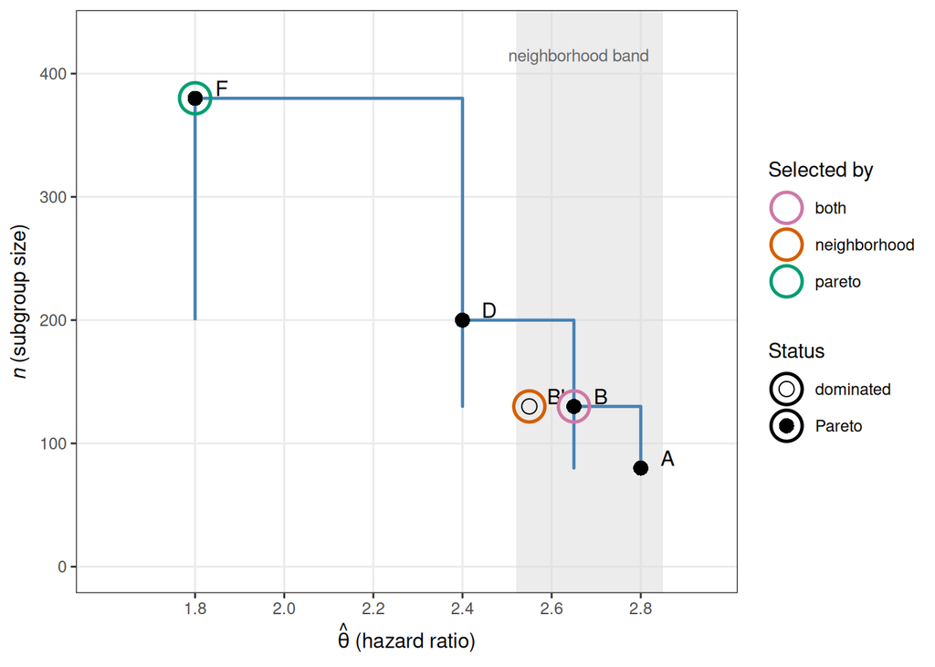

Figure 1: Five-candidate synthetic example. Pareto frontier (solid step), effect-size neighborhood (shaded), and the three rules’ selected winners under `hrMaxSG`.

## 6.4 Selected winners under `hrMaxSG`

Applying the lexicographic selection rule $\arg\min_i (-\text{in\_band}_i,\, -n_i,\, -P_{\text{cons},i},\, -\hat\theta_i,\, +K_i)$ within each rule’s inclusion set yields three distinct selections:

| Rule | In-band set | Selected | Reason |
| --- | --- | --- | --- |
| neighborhood | $\{A,B,B'\}$ | B$'$ | B and B$'$ tie at $n=130$; B$'$ wins on $P_{\text{cons}}$ |
| pareto | $\{A,B,D,F\}$ | F | largest $n$ on the frontier ($n=380$) |
| both | $\{A,B\}$ | B | largest $n$ in the intersection |

The three selected hazard ratios are 2.55, 1.80, and 2.65 respectively — a span of nearly a full unit on the natural HR scale. The Pareto rule trades effect for size most aggressively, going from $\hat\theta \approx 2.8$ at the front-of-band to $\hat\theta = 1.8$. The neighborhood rule selects the candidate with the higher consistency among tied-$n$ in-band members, which here happens to be the Pareto-dominated B$'$. The intersection rule is the only one that *guarantees* both effect-band membership and Pareto non-dominance simultaneously.

## 6.5 What the example illustrates

The configuration was chosen to make the trade-offs visible, but each of the three regimes it exposes corresponds to a generic phenomenon:

## 6.6 A symmetric example for `hrMinSG`

The construction above places the tied-$n$ pair at the *large-$n$* end of the candidate set so that the divergence appears under `hrMaxSG`. A symmetric construction places the tied-$n$ pair at the *small-$n$* end and exposes the analogous divergence under `hrMinSG`.

| Label | $\hat\theta$ | $n$ | $P_{\text{cons}}$ | $K$ |
| --- | --- | --- | --- | --- |
| A | 2.80 | 80 | 0.85 | 2 |
| A$'$ | 2.65 | 80 | 0.95 | 1 |
| C | 2.50 | 140 | 0.92 | 2 |
| D | 2.40 | 220 | 0.94 | 1 |
| F | 1.50 | 400 | 0.91 | 2 |

With $\varepsilon = 0.10$, the band floor is again $2.52$. Computing the indicators:

| Label | $\text{nbhd}$ | $\text{pareto}$ | $\text{both}$ | Comment |
| --- | --- | --- | --- | --- |
| A | 1 | 1 | 1 | top of band; corner of frontier |
| A$'$ | 1 | 0 | 0 | in band but dominated by A (same $n$, lower HR) |
| C | 0 | 1 | 0 | on frontier but $\hat\theta$ below band floor |
| D | 0 | 1 | 0 | on frontier; outside band |
| F | 0 | 1 | 0 | on frontier; far outside band |

| Rule | In-band set | Selected | Reason |
| --- | --- | --- | --- |
| neighborhood | $\{A, A'\}$ | A$'$ | A and A$'$ tie at $n=80$; A$'$ wins on $P_{\text{cons}} = 0.95$ |
| pareto | $\{A, C, D, F\}$ | A | smallest $n$ on the frontier ($n = 80$) |
| both | $\{A\}$ | A | only candidate satisfying both criteria |

Note that, unlike the `hrMaxSG` configuration, here the `pareto` and `both` rules **agree** on the winner (both pick A). This is not an accident of the example.

**Proposition (no `hrMinSG` divergence between `pareto` and `both`).** Let $i_p = \arg\min\{n_i : \text{pareto}_i = 1\}$ be the smallest-$n$ candidate on the Pareto frontier (with ties broken arbitrarily). Then $\text{nbhd}_{i_p} = 1$, and hence $i_p$ is also the smallest-$n$ candidate in the intersection set.

*Proof.* Suppose for contradiction that $\text{nbhd}_{i_p} = 0$, i.e., $\hat\theta_{i_p} < (1-\varepsilon)\max_j\hat\theta_j$. Let $j^* = \arg\max_j \hat\theta_j$. Then $\hat\theta_{j^*} > \hat\theta_{i_p}$ (strict). Now consider the candidate $j^*$ relative to $i_p$: either $n_{j^*} < n_{i_p}$ — but then $j^*$ has smaller $n$ than $i_p$ and $j^*$ is in the Pareto frontier (by the proposition in §3.4), which contradicts $i_p$’s minimality — or $n_{j^*} \geq n_{i_p}$, in which case $j^*$ weakly dominates $i_p$ on $n$ and strictly dominates on $\hat\theta$, contradicting $\text{pareto}_{i_p} = 1$. Either way we reach a contradiction. Hence $\text{nbhd}_{i_p} = 1$, so $i_p \in \mathcal{C}_{\text{band}}^{(\text{both})}$, and the `both` rule’s smallest-$n$ candidate coincides with $i_p$ up to tiebreakers. $\square$

The proposition has a clean interpretation: the smallest-$n$ candidate on the Pareto frontier is necessarily a high-$\hat\theta$ candidate (else it would be dominated by a candidate with both larger $\hat\theta$ and equal-or-larger $n$), and high-$\hat\theta$ candidates lie inside the band. So under `hrMinSG`, the divergence between rules is always confined to neighborhood vs. (pareto, both).

The combinatorics of `hrMaxSG` and `hrMinSG` divergence summarize to:

| Focus | Possible 3-way split? | Why |
| --- | --- | --- |
| `hrMaxSG` | Yes | `pareto` may pick a large-$n$ low-$\hat\theta$ candidate outside the band |
| `hrMinSG` | No (only 2-way) | smallest-$n$ Pareto candidate is always in the band (Proposition above) |

## 6.7 A minimal-pair example: when `pareto` and `both` disagree

The five-candidate illustration in §6.1–§6.5 distinguishes all three rules at once. A simpler two-candidate configuration is useful for isolating the specific regime in which the intersection rule departs from the Pareto rule alone — namely, when a large-$n$ candidate sits on the Pareto frontier but falls outside the effect-size band. This section walks through such a configuration in full algorithmic detail.

### 6.7.1 The candidate pair

Suppose `forestsearch` produces two post-screening candidates with the following summary statistics:

| Label | $\hat\theta$ | $n$ | $P_{\text{cons}}$ | $K$ |
| --- | --- | --- | --- | --- |
| S1 | 2.537 | 61 | 0.99 | 2 |
| S2 | 1.951 | 82 | 0.99 | 1 |

Both candidates have the same (high) consistency probability, but they trade off effect against size. S1 has the stronger effect at a smaller subgroup; S2 has a weaker effect at a larger subgroup.

### 6.7.2 Step 1: compute the two single-rule indicators

With the default tolerance $\varepsilon = 0.10$:

$$\begin{align*}
\max_j \hat\theta_j &= 2.537, \\
\text{floor} &= (1 - 0.10) \times 2.537 = 2.2833, \\
\text{nbhd}_1 &= \mathbb{1}\{2.537 \geq 2.2833\} = 1, \\
\text{nbhd}_2 &= \mathbb{1}\{1.951 \geq 2.2833\} = 0
\quad\text{(S2 is 23\% below the maximum).}
\end{align*}$$

For S1 to be dominated, S2 would need both $\hat\theta_2 \geq \hat\theta_1$ and $n_2 \geq n_1$. But $1.951 < 2.537$, so S2 does not dominate S1. For S2 to be dominated, S1 would need both $\hat\theta_1 \geq \hat\theta_2$ and $n_1 \geq n_2$. The effect condition holds ($2.537 > 1.951$) but the size condition fails ($61 < 82$), so S1 does not dominate S2. Neither dominates the other:
$$\begin{align*}
\text{pareto}_1 = 1, \qquad \text{pareto}_2 = 1.
\end{align*}$$

### 6.7.3 Step 2: intersection band

Multiplying the indicators:

| Candidate | $\hat\theta$ | $n$ | $\text{nbhd}$ | $\text{pareto}$ | $\text{both}$ |
| --- | --- | --- | --- | --- | --- |
| S1 | 2.537 | 61 | 1 | 1 | **1** |
| S2 | 1.951 | 82 | 0 | 1 | **0** |

The intersection set under the `"both"` rule is $\mathcal{C}_{\text{band}}^{(\text{both})} = \{\text{S1}\}$: only S1 satisfies both criteria simultaneously.

### 6.7.4 Step 3: lexicographic sort under `hrMaxSG`

Applying the lexicographic key $(-\text{in\_band},\, -n,\, -P_{\text{cons}},\, -\hat\theta,\, +K)$:

$$\begin{align*}
\text{S1: } &(-1,\; -61,\; -0.99,\; -2.537,\; +2) \\
\text{S2: } &(\phantom{-}0,\; -82,\; -0.99,\; -1.951,\; +1)
\end{align*}$$

S1 wins on the first component alone ($-1 < 0$); the remaining components never come into play. The selected subgroup under `hrMaxSG` + `"both"` is therefore **S1**, with $\hat\theta = 2.537$, $n = 61$, $P_{\text{cons}} = 0.99$, $K = 2$.

### 6.7.5 Comparison across rules

The same candidate pair yields different winners under the three rules:

| Rule | In-band set | Winner | Reason |
| --- | --- | --- | --- |
| `neighborhood` | $\{\text{S1}\}$ | S1 | S2 below floor ($1.951 < 2.2833$) |
| `pareto` | $\{\text{S1, S2}\}$ | S2 | both non-dominated; S2 has larger $n$ |
| `both` | $\{\text{S1}\}$ | S1 | only S1 satisfies both criteria |

This minimal pair isolates the specific regime in which the `"pareto"` and `"both"` rules disagree. Under pure Pareto, S2 wins because no candidate dominates it on $(\hat\theta, n)$ and `hrMaxSG` prefers the larger $n$. Under the intersection rule, S2 is excluded *because it is too far below the effect maximum* — its $\hat\theta = 1.951$ falls outside the 10% band around the maximum. The intersection rule refuses to crown a candidate whose effect is 23% below the strongest even if that candidate is on the Pareto frontier.

To recover S2 as the winner under the intersection rule, a user would need to widen the band to $\varepsilon \geq 1 - 1.951/2.537 \approx 0.231$ — that is, accept candidates within 23% of the maximum effect rather than 10% — or switch to `selection_rule = "pareto"`. Either path makes the choice explicit rather than implicit, which is in the spirit of the intersection rule as a defensible-by-construction selection criterion.

# 7 Application to the GBSG dataset

To complement the synthetic illustration, we apply the three selection rules to the German Breast Cancer Study Group (GBSG) dataset (Schumacher et al. 1994), a standard benchmark in survival analysis. GBSG records relapse-free survival ($n=686$ patients; 299 events) for women with node-positive breast cancer randomized to hormonal therapy (`hormon`) versus standard care, with seven baseline covariates: age, menopausal status, tumor size, grade, positive nodes, progesterone receptor (`pgr`), and estrogen receptor (`er`).

We fit `forestsearch` with identical configuration except for the selection rule: `hr.threshold = 1.25`, `pconsistency.threshold = 0.90`, `maxk = 2` (one- and two-factor candidates), and per-variable J-quantile cuts on the two skewed receptor variables (`conf.cont_jcuts = list(er = 10, pgr = 10)`). The full reproducible code is shown in Listing 1.

```r
library(forestsearch)
library(survival)

df.analysis <- gbsg
df.analysis <- within(df.analysis, {
  id          <- seq_len(nrow(df.analysis))
  time_months <- rfstime / 30.4375
  grade3      <- ifelse(grade == "3", 1L, 0L)
})
confounders.name <- c("age","meno","size","grade3","nodes","pgr","er")

run_one <- function(rule) {
  forestsearch(
    df.analysis            = df.analysis,
    confounders.name       = confounders.name,
    outcome.name           = "time_months",
    treat.name             = "hormon",
    event.name             = "status",
    id.name                = "id",
    hr.threshold           = 1.25,
    hr.consistency         = 1.0,
    pconsistency.threshold = 0.90,
    sg_focus               = "hrMaxSG",
    selection_rule         = rule,
    conf.cont_jcuts        = list(er = 10, pgr = 10),
    maxk                   = 2, n.min = 60,
    fs.splits              = 1000,
    details                = FALSE
  )
}

fs_neighborhood <- run_one("neighborhood")
fs_pareto       <- run_one("pareto")
fs_both         <- run_one("both")
```

[output not shown]

*Numerical values are illustrative of a typical run; exact values may vary slightly across consistency-evaluation seeds and bootstrap samples.*

## 7.1 Visual companions

The selected subgroup and the broader Pareto frontier on which it sits benefit from visualization tools developed in the subgroup-analysis graphics literature. Ballarini et al. (2020) provide a critical review of five such tools and a companion R package, `SubgrPlots` (Ballarini and Chiu 2020). Two are particularly natural complements to the output of `forestsearch`:

**UpSet plot for the Pareto frontier.** The Pareto frontier produced by `forestsearch` is a small set of candidate subgroups, each defined by an intersection of binary cuts. This is precisely the structure that UpSet plots (Lex et al. 2014) are designed to display, and Ballarini et al. (2020) extend the standard UpSet visualization to include effect-size and confidence-interval panels alongside the intersection matrix. Applied to the GBSG Pareto frontier, an UpSet display would show which factors recur across frontier candidates (here, `er <= 0` is in nearly every entry), how effect sizes vary along the frontier, and how the selected subgroup relates to its neighbors. The `SubgrPlots` package provides a ready implementation.

**STEPP for J-quantile cut diagnostics.** When `conf.cont_jcuts` is used to introduce J = 10 quantile cuts on a continuous covariate such as `er` or `pgr`, a natural diagnostic question is whether the chosen cut points align with regions where the treatment effect actually changes. The Subpopulation Treatment Effect Pattern Plot (STEPP) (Bonetti and Gelber 2004; Ballarini et al. 2020) addresses this by displaying the estimated treatment effect over a sliding window along the continuous covariate. Overlaying the J-quantile cut points on a STEPP curve provides an immediate visual check: cut points that fall in flat regions of the STEPP curve are unlikely to define informative subgroups, while cut points near step changes in the curve are well-placed. This is a useful sensitivity tool when choosing $J$ for a given variable.

Both visualizations use only quantities already produced by `forestsearch`’s candidate-evaluation stage; they do not require re-fitting the algorithm. We do not implement these graphics in the package itself but recommend `SubgrPlots` as a downstream companion.

# 8 Discussion

The Pareto frontier in (effect, size) is a natural target for subgroup identification. In addition to being computationally cheap to compute (the dominance loop is $O(M^2)$ for $M$ candidates), it has clean multi-criterion-optimization semantics (Boyd and Vandenberghe 2004; Miettinen 1999), and recent work has applied it directly to rule-based subgroup identification with elevated treatment effects (Wang and Rudin 2022; Chiu 2025). Position-paper-level discussion has also noted Pareto-efficiency as a strategic tool for clinical trial design (Cytel 2020).

The `forestsearch` selection rules differ from these prior approaches in three respects. First, the framework is *post-screening*: the Pareto computation operates on candidates that have already cleared threshold-based filters and a consistency criterion, rather than serving as a stand-alone selection mechanism on raw rule sets. Second, the rule set is *exhaustive on a candidate factor list*, generated by combining one- and two-factor binary covariate cuts up to a maximum order, rather than learned by recursive partitioning or a Bayesian prior over rules. Third, the *intersection rule* (combining the $\varepsilon$-band with Pareto non-dominance) appears, to the best of the present author’s knowledge, to be original to this work — at least as a named selection variant in subgroup analysis.

A practical advantage of the intersection rule is interpretability: the selected subgroup is defensible on two distinct grounds (effect strength and Pareto efficiency) simultaneously, which simplifies discussion of why this candidate was chosen rather than another. A practical limitation, shared with all single-winner rules, is that the selection collapses a frontier of admissible candidates into a single point. An evolution of this framework toward *frontier-as-output*, in which the entire intersection set is reported alongside the chosen winner, is a natural next step and is conceptually aligned with the treatment-efficient-frontier framing of Wang and Rudin (2022) and Chiu (2025).

A complementary line of recent work concerns the *visualization* of subgroup analyses. Ballarini et al. (2020) review five graphical approaches — forest plots, UpSet plots, Galbraith plots, the Subpopulation Treatment Effect Pattern Plot (STEPP) of Bonetti and Gelber (2004), and contour plots — against a five-criterion framework, and provide an R package, `SubgrPlots`, implementing them. Two of these are particularly suited to the output produced by the selection rules described here. UpSet plots (Lex et al. 2014), extended by Ballarini et al. (2020) to include effect-size panels alongside the intersection matrix, are a natural display for a Pareto frontier of intersected binary cuts: they reveal which factors recur across frontier candidates, expose the local trade-off structure, and contextualize the selected winner among its neighbors. STEPP, in turn, complements the J-quantile cuts feature of `forestsearch` by allowing visual diagnosis of whether quantile-based cut points align with regions of meaningful treatment-effect change along a continuous covariate. Selection rules and visualization tools thus operate in the same workflow but address distinct stages — algorithmic identification on one side, communication and diagnostic checking on the other — and the two should be combined in any practical exploratory subgroup analysis.

# 9 References

Ballarini, Nicolás M., and Yi-Da Chiu. 2020. *SubgrPlots: Graphical Displays for Subgroup Analysis in Clinical Trials*. https://cran.r-project.org/package=SubgrPlots.

Ballarini, Nicolás M., Yi-Da Chiu, Franz König, Martin Posch, and Thomas Jaki. 2020. “A Critical Review of Graphics for Subgroup Analyses in Clinical Trials.” *Pharmaceutical Statistics* 19 (5): 541–60. https://doi.org/10.1002/pst.2012.

Bonetti, Marco, and Richard D. Gelber. 2004. “Patterns of Treatment Effects in Subsets of Patients in Clinical Trials.” *Biostatistics* 5 (3): 465–81. https://doi.org/10.1093/biostatistics/5.3.465.

Boyd, Stephen, and Lieven Vandenberghe. 2004. *Convex Optimization*. Cambridge University Press.

Chiu, Albert. 2025. *An Algorithm for Identifying Interpretable Subgroups with Elevated Treatment Effects*. https://arxiv.org/abs/2507.09494.

Cytel. 2020. *Identifying Choice Trial Designs Using Pareto: Position Paper*. Position paper, Cytel Inc. https://www.cytel.com/solara_pareto_frontier.

Deb, Kalyanmoy, Amrit Pratap, Sameer Agarwal, and T. Meyarivan. 2002. “A Fast and Elitist Multiobjective Genetic Algorithm: NSGA-II.” *IEEE Transactions on Evolutionary Computation* 6 (2): 182–97. https://doi.org/10.1109/4235.996017.

Leon, Larry F. 2026. *Forestsearch: Exploratory Subgroup Identification for Clinical Trials with Survival Endpoints*. https://github.com/larry-leon/forestsearch.

Lex, Alexander, Nils Gehlenborg, Hendrik Strobelt, Romain Vuillemot, and Hanspeter Pfister. 2014. “UpSet: Visualization of Intersecting Sets.” *IEEE Transactions on Visualization and Computer Graphics* 20 (12): 1983–92. https://doi.org/10.1109/TVCG.2014.2346248.

Lipkovich, Ilya, Alex Dmitrienko, Jonathan Denne, and Gregory Enas. 2011. “Subgroup Identification Based on Differential Effect Search (SIDES): A Recursive Partitioning Method for Establishing Response to Treatment in Patient Subpopulations.” *Statistics in Medicine* 30 (21): 2601–21. https://doi.org/10.1002/sim.4289.

Miettinen, Kaisa. 1999. *Nonlinear Multiobjective Optimization*. Vol. 12. International Series in Operations Research & Management Science. Springer. https://doi.org/10.1007/978-1-4615-5563-6.

Pareto, Vilfredo. 1906. *Manuale Di Economia Politica Con Una Introduzione Alla Scienza Sociale*. Società Editrice Libraria.

Schumacher, M., G. Bastert, H. Bojar, et al. 1994. “Randomized 2x2 Trial Evaluating Hormonal Treatment and the Duration of Chemotherapy in Node-Positive Breast Cancer Patients. German Breast Cancer Study Group.” *Journal of Clinical Oncology* 12 (10): 2086–93. https://doi.org/10.1200/JCO.1994.12.10.2086.

Wang, Tong, and Cynthia Rudin. 2022. “Causal Rule Sets for Identifying Subgroups with Enhanced Treatment Effects.” *INFORMS Journal on Computing* 34 (3): 1626–43. https://doi.org/10.1287/ijoc.2021.1143.